# Analiza danych covid-19

Klaudia Pytel

Ostatnia aktualizacja: 06 czerwiec, 2021

# Informacje o projekcie

### Spis wykorzystanych bibliotek

```r
library(Hmisc)
library(dplyr)
library(tidyr)
library(caret)
library(mlbench)
```

# Wstępna analiza danych

### Wygląd danych źródłowych po przetworzeniu

| id | sample_date | age | gender | hs_ctnt | hgb | serum_cl | pt | pct |
| --- | --- | --- | --- | --- | --- | --- | --- | --- |
| 1 | 2020-01-31 01:09:00 | 73 | 1 | NA | NA | NA | NA | NA |
| 1 | 2020-01-31 01:25:00 | 73 | 1 | NA | 136 | NA | NA | NA |
| 1 | 2020-01-31 01:44:00 | 73 | 1 | NA | NA | 103.1 | NA | NA |
| 1 | 2020-01-31 01:45:00 | 73 | 1 | NA | NA | NA | 13.9 | NA |
| 1 | 2020-01-31 01:56:00 | 73 | 1 | 19.9 | NA | NA | NA | 0.09 |
| 1 | 2020-01-31 01:59:00 | 73 | 1 | NA | NA | NA | NA | NA |

### Analiza atrybutów

wuhan_df[-1:-8]  
73 Variables 6120 Observations

hgb

| n | missing | distinct | Info | Mean | Gmd | .05 | .10 | .25 | .50 | .75 | .90 | .95 |
| --- | --- | --- | --- | --- | --- | --- | --- | --- | --- | --- | --- | --- |
| 975 | 5145 | 115 | 1 | 123.1 | 23.87 | 91.0 | 101.0 | 113.0 | 125.0 | 137.0 | 149.0 | 154.3 |

lowest : 6.4 10.9 11.6 12.5 12.9 , highest: 167.0 168.0 170.0 171.0 178.0

serum_cl

| n | missing | distinct | Info | Mean | Gmd | .05 | .10 | .25 | .50 | .75 | .90 | .95 |
| --- | --- | --- | --- | --- | --- | --- | --- | --- | --- | --- | --- | --- |
| 975 | 5145 | 294 | 1 | 103.1 | 7.97 | 93.07 | 95.60 | 99.05 | 102.10 | 105.65 | 112.46 | 118.63 |

lowest : 71.5 76.0 77.7 83.0 83.9 , highest: 134.6 138.2 140.0 140.3 140.4

pt

| n | missing | distinct | Info | Mean | Gmd | .05 | .10 | .25 | .50 | .75 | .90 | .95 |
| --- | --- | --- | --- | --- | --- | --- | --- | --- | --- | --- | --- | --- |
| 662 | 5458 | 130 | 1 | 16.67 | 5.024 | 12.7 | 13.0 | 13.6 | 14.8 | 16.7 | 19.5 | 23.6 |

lowest : 11.5 11.6 11.8 12.0 12.1 , highest: 54.7 59.5 92.1 104.8 120.0

pct

| n | missing | distinct | Info | Mean | Gmd | .05 | .10 | .25 | .50 | .75 | .90 | .95 |
| --- | --- | --- | --- | --- | --- | --- | --- | --- | --- | --- | --- | --- |
| 459 | 5661 | 133 | 0.995 | 1.107 | 1.937 | 0.020 | 0.020 | 0.040 | 0.100 | 0.405 | 1.446 | 4.548 |

lowest : 0.02 0.03 0.04 0.05 0.06 , highest: 28.15 28.45 38.92 42.71 57.17

eos_p

| n | missing | distinct | Info | Mean | Gmd | .05 | .10 | .25 | .50 | .75 | .90 | .95 |
| --- | --- | --- | --- | --- | --- | --- | --- | --- | --- | --- | --- | --- |
| 957 | 5163 | 54 | 0.895 | 0.6289 | 0.9337 | 0.0 | 0.0 | 0.0 | 0.1 | 0.8 | 2.0 | 2.8 |

lowest : 0.0 0.1 0.2 0.3 0.4 , highest: 5.8 6.4 7.1 7.2 8.6

il_2r

| n | missing | distinct | Info | Mean | Gmd | .05 | .10 | .25 | .50 | .75 | .90 | .95 |
| --- | --- | --- | --- | --- | --- | --- | --- | --- | --- | --- | --- | --- |
| 268 | 5852 | 253 | 1 | 907.2 | 693.6 | 245.1 | 310.9 | 459.5 | 676.5 | 1155.5 | 1644.5 | 2147.0 |

lowest : 61 70 80 123 125 , highest: 3516 3638 4201 5358 7500

salp

| n | missing | distinct | Info | Mean | Gmd | .05 | .10 | .25 | .50 | .75 | .90 | .95 |
| --- | --- | --- | --- | --- | --- | --- | --- | --- | --- | --- | --- | --- |
| 930 | 5190 | 168 | 1 | 82.47 | 43.36 | 41.0 | 45.0 | 54.0 | 69.5 | 95.0 | 136.0 | 172.5 |

lowest : 17 20 22 23 29 , highest: 269 283 284 424 620

hsa

| n | missing | distinct | Info | Mean | Gmd | .05 | .10 | .25 | .50 | .75 | .90 | .95 |
| --- | --- | --- | --- | --- | --- | --- | --- | --- | --- | --- | --- | --- |
| 934 | 5186 | 258 | 1 | 32.01 | 7.139 | 21.7 | 23.6 | 27.4 | 32.2 | 36.6 | 39.8 | 41.7 |

lowest : 13.6 15.3 16.4 16.7 16.9 , highest: 45.7 46.0 46.3 47.6 48.6

baso_p

| n | missing | distinct | Info | Mean | Gmd | .05 | .10 | .25 | .50 | .75 | .90 | .95 |
| --- | --- | --- | --- | --- | --- | --- | --- | --- | --- | --- | --- | --- |
| 957 | 5163 | 17 | 0.956 | 0.2099 | 0.2128 | 0.0 | 0.0 | 0.1 | 0.2 | 0.3 | 0.5 | 0.6 |

lowest : 0.0 0.1 0.2 0.3 0.4 , highest: 1.3 1.4 1.5 1.6 1.7

```
 Value        0.0   0.1   0.2   0.3   0.4   0.5   0.6   0.7   0.8   0.9   1.0   1.1
 Frequency    195   273   209   100    72    44    25     8    13     8     2     3
 Proportion 0.204 0.285 0.218 0.104 0.075 0.046 0.026 0.008 0.014 0.008 0.002 0.003

 Value        1.3   1.4   1.5   1.6   1.7
 Frequency      1     1     1     1     1
 Proportion 0.001 0.001 0.001 0.001 0.001
```

il_10

| n | missing | distinct | Info | Mean | Gmd | .05 | .10 | .25 | .50 | .75 | .90 | .95 |
| --- | --- | --- | --- | --- | --- | --- | --- | --- | --- | --- | --- | --- |
| 267 | 5853 | 107 | 0.909 | 16.07 | 19.3 | 5.00 | 5.00 | 5.00 | 5.90 | 12.35 | 19.56 | 27.28 |

lowest : 5.0 5.1 5.2 5.3 5.4 , highest: 73.7 93.3 104.0 500.0 1000.0

```
 Value          0    10    20    30    40    50    70    90   100   500  1000
 Frequency    120    97    31    10     2     1     2     1     1     1     1
 Proportion 0.449 0.363 0.116 0.037 0.007 0.004 0.007 0.004 0.004 0.004 0.004
```

For the frequency table, variable is rounded to the nearest 10

br_t

| n | missing | distinct | Info | Mean | Gmd | .05 | .10 | .25 | .50 | .75 | .90 | .95 |
| --- | --- | --- | --- | --- | --- | --- | --- | --- | --- | --- | --- | --- |
| 930 | 5190 | 302 | 1 | 16.7 | 15.24 | 4.40 | 5.39 | 7.40 | 10.70 | 16.78 | 29.10 | 42.02 |

lowest : 2.5 2.8 2.9 3.0 3.1 , highest: 174.1 175.0 276.0 295.4 505.7

mpv_c

| n | missing | distinct | Info | Mean | Gmd | .05 | .10 | .25 | .50 | .75 | .90 | .95 |
| --- | --- | --- | --- | --- | --- | --- | --- | --- | --- | --- | --- | --- |
| 957 | 5163 | 358 | 1 | 184.3 | 117.3 | 24.0 | 42.0 | 109.0 | 178.0 | 248.0 | 315.0 | 371.8 |

lowest : -1 4 6 7 8 , highest: 544 549 550 554 558

mono_p

| n | missing | distinct | Info | Mean | Gmd | .05 | .10 | .25 | .50 | .75 | .90 | .95 |
| --- | --- | --- | --- | --- | --- | --- | --- | --- | --- | --- | --- | --- |
| 958 | 5162 | 157 | 1 | 6.155 | 4.258 | 1.30 | 1.80 | 2.80 | 5.70 | 8.60 | 11.00 | 12.63 |

lowest : 0.3 0.4 0.5 0.6 0.7 , highest: 19.4 20.4 23.1 35.2 53.0

at

| n | missing | distinct | Info | Mean | Gmd | .05 | .10 | .25 | .50 | .75 | .90 | .95 |
| --- | --- | --- | --- | --- | --- | --- | --- | --- | --- | --- | --- | --- |
| 330 | 5790 | 84 | 1 | 85.32 | 20.36 | 52.45 | 63.90 | 74.00 | 86.00 | 97.00 | 108.10 | 115.55 |

lowest : 20 33 36 41 42 , highest: 125 126 128 130 136

il_8

```
        n  missing distinct     Info     Mean      Gmd      .05      .10      .25
      268     5852      185    0.999    83.09    137.1    5.000    5.440    8.675
      .50      .75      .90      .95
   16.000   35.200   78.410  125.650
```

lowest : 5.0 5.1 5.3 5.5 5.6 , highest: 384.0 436.0 443.0 6003.0 6795.0

```
 Value          0    50   100   150   200   250   300   400   450  6000  6800
 Frequency    173    66    15     1     4     2     2     1     2     1     1
 Proportion 0.646 0.246 0.056 0.004 0.015 0.007 0.007 0.004 0.007 0.004 0.004
```

For the frequency table, variable is rounded to the nearest 50

indirect_br

| n | missing | distinct | Info | Mean | Gmd | .05 | .10 | .25 | .50 | .75 | .90 | .95 |
| --- | --- | --- | --- | --- | --- | --- | --- | --- | --- | --- | --- | --- |
| 906 | 5214 | 166 | 1 | 6.889 | 4.96 | 2.025 | 2.600 | 3.800 | 5.400 | 8.000 | 11.900 | 15.150 |

lowest : 0.1 0.4 0.8 1.0 1.1 , highest: 45.9 50.2 52.5 59.7 145.1

rdw

| n | missing | distinct | Info | Mean | Gmd | .05 | .10 | .25 | .50 | .75 | .90 | .95 |
| --- | --- | --- | --- | --- | --- | --- | --- | --- | --- | --- | --- | --- |
| 923 | 5197 | 79 | 0.999 | 13.07 | 1.637 | 11.40 | 11.62 | 12.00 | 12.60 | 13.70 | 15.00 | 16.00 |

lowest : 10.6 10.7 10.8 10.9 11.0 , highest: 24.1 24.2 24.6 25.1 27.1

neut_p

| n | missing | distinct | Info | Mean | Gmd | .05 | .10 | .25 | .50 | .75 | .90 | .95 |
| --- | --- | --- | --- | --- | --- | --- | --- | --- | --- | --- | --- | --- |
| 957 | 5163 | 436 | 1 | 77.6 | 18.45 | 48.36 | 53.46 | 65.10 | 82.40 | 92.30 | 95.10 | 96.10 |

lowest : 1.7 1.9 18.2 28.9 29.0 , highest: 98.0 98.1 98.2 98.7 98.9

p_t

| n | missing | distinct | Info | Mean | Gmd | .05 | .10 | .25 | .50 | .75 | .90 | .95 |
| --- | --- | --- | --- | --- | --- | --- | --- | --- | --- | --- | --- | --- |
| 931 | 5189 | 295 | 1 | 65.3 | 8.478 | 50.85 | 55.20 | 61.00 | 65.90 | 70.45 | 74.20 | 76.90 |

lowest : 31.8 36.7 37.0 39.0 41.3 , highest: 82.5 83.3 83.4 84.5 88.7

quant_t_palladium_ab

| n | missing | distinct | Info | Mean | Gmd | .05 | .10 | .25 | .50 | .75 | .90 | .95 |
| --- | --- | --- | --- | --- | --- | --- | --- | --- | --- | --- | --- | --- |
| 279 | 5841 | 25 | 0.977 | 0.1324 | 0.1754 | 0.030 | 0.030 | 0.040 | 0.050 | 0.070 | 0.102 | 0.140 |

lowest : 0.02 0.03 0.04 0.05 0.06 , highest: 0.41 1.32 2.62 4.09 11.95

```
 Value       0.02  0.04  0.06  0.08  0.10  0.12  0.14  0.16  0.18  0.20  0.22  0.38
 Frequency     42   114    62    27    13     6     3     1     3     1     1     1
 Proportion 0.151 0.409 0.222 0.097 0.047 0.022 0.011 0.004 0.011 0.004 0.004 0.004

 Value       0.40  1.32  2.62  4.08 11.94
 Frequency      1     1     1     1     1
 Proportion 0.004 0.004 0.004 0.004 0.004
```

For the frequency table, variable is rounded to the nearest 0.02

pt_activity

| n | missing | distinct | Info | Mean | Gmd | .05 | .10 | .25 | .50 | .75 | .90 | .95 |
| --- | --- | --- | --- | --- | --- | --- | --- | --- | --- | --- | --- | --- |
| 659 | 5461 | 111 | 1 | 78.55 | 24.78 | 38.9 | 50.8 | 65.0 | 81.0 | 95.0 | 104.0 | 109.0 |

lowest : 6 7 12 13 15 , highest: 127 128 133 137 142

hbsag

| n | missing | distinct | Info | Mean | Gmd | .05 | .10 | .25 | .50 | .75 | .90 | .95 |
| --- | --- | --- | --- | --- | --- | --- | --- | --- | --- | --- | --- | --- |
| 279 | 5841 | 15 | 0.865 | 8.306 | 16.09 | 0.00 | 0.00 | 0.00 | 0.01 | 0.01 | 0.02 | 5.79 |

lowest : 0.00 0.01 0.02 0.03 0.04 , highest: 28.27 30.40 56.32 162.19 250.00

```
 Value        0.00   0.01   0.02   0.03   0.04   3.65   4.01   5.30  10.20  15.25
 Frequency     119    107     29      6      1      1      1      1      1      1
 Proportion  0.427  0.384  0.104  0.022  0.004  0.004  0.004  0.004  0.004  0.004

 Value       28.27  30.40  56.32 162.19 250.00
 Frequency       1      1      1      1      8
 Proportion  0.004  0.004  0.004  0.004  0.029
```

mcv

| n | missing | distinct | Info | Mean | Gmd | .05 | .10 | .25 | .50 | .75 | .90 | .95 |
| --- | --- | --- | --- | --- | --- | --- | --- | --- | --- | --- | --- | --- |
| 957 | 5163 | 260 | 1 | 90.39 | 6.902 | 81.48 | 83.70 | 86.90 | 90.10 | 93.90 | 97.94 | 100.52 |

lowest : 61.6 62.3 63.5 65.2 65.8 , highest: 113.3 114.6 117.6 117.8 118.9

ht

| n | missing | distinct | Info | Mean | Gmd | .05 | .10 | .25 | .50 | .75 | .90 | .95 |
| --- | --- | --- | --- | --- | --- | --- | --- | --- | --- | --- | --- | --- |
| 957 | 5163 | 236 | 1 | 36.54 | 5.852 | 27.88 | 30.30 | 33.50 | 36.60 | 39.90 | 43.20 | 45.20 |

lowest : 14.5 15.6 15.7 15.9 16.0 , highest: 50.1 50.4 51.3 51.7 52.3

wb_c

| n | missing | distinct | Info | Mean | Gmd | .05 | .10 | .25 | .50 | .75 | .90 | .95 |
| --- | --- | --- | --- | --- | --- | --- | --- | --- | --- | --- | --- | --- |
| 1127 | 4993 | 815 | 1 | 15.6 | 18.57 | 2.959 | 3.576 | 4.940 | 7.720 | 12.720 | 19.602 | 25.463 |

lowest : 0.13 0.35 0.70 0.71 0.80 , highest: 404.20 605.80 704.70 831.20 1726.60

```
 Value          0    20    40    60    80   100   140   160   200   220   240   340
 Frequency    725   358    23     3     2     1     1     2     1     1     3     2
 Proportion 0.643 0.318 0.020 0.003 0.002 0.001 0.001 0.002 0.001 0.001 0.003 0.002

 Value        400   600   700   840  1720
 Frequency      1     1     1     1     1
 Proportion 0.001 0.001 0.001 0.001 0.001
```

For the frequency table, variable is rounded to the nearest 20

thf_alpha

| n | missing | distinct | Info | Mean | Gmd | .05 | .10 | .25 | .50 | .75 | .90 | .95 |
| --- | --- | --- | --- | --- | --- | --- | --- | --- | --- | --- | --- | --- |
| 268 | 5852 | 119 | 1 | 11.58 | 8.141 | 4.70 | 5.47 | 6.70 | 8.60 | 11.50 | 18.30 | 27.35 |

lowest : 4.0 4.6 4.7 4.9 5.0 , highest: 54.2 59.6 60.5 70.4 168.0

mchc

| n | missing | distinct | Info | Mean | Gmd | .05 | .10 | .25 | .50 | .75 | .90 | .95 |
| --- | --- | --- | --- | --- | --- | --- | --- | --- | --- | --- | --- | --- |
| 957 | 5163 | 94 | 0.999 | 342.8 | 17.52 | 317.0 | 324.0 | 333.0 | 343.0 | 350.0 | 359.0 | 366.2 |

lowest : 286 299 300 301 303 , highest: 442 451 469 488 514

fibrinogen

| n | missing | distinct | Info | Mean | Gmd | .05 | .10 | .25 | .50 | .75 | .90 | .95 |
| --- | --- | --- | --- | --- | --- | --- | --- | --- | --- | --- | --- | --- |
| 566 | 5554 | 376 | 1 | 4.294 | 2.131 | 1.150 | 1.665 | 3.050 | 4.120 | 5.480 | 6.805 | 7.478 |

lowest : 0.50 0.60 0.62 0.63 0.66 , highest: 8.97 9.63 9.69 10.59 10.78

il_1beta

| n | missing | distinct | Info | Mean | Gmd | .05 | .10 | .25 | .50 | .75 | .90 | .95 |
| --- | --- | --- | --- | --- | --- | --- | --- | --- | --- | --- | --- | --- |
| 268 | 5852 | 33 | 0.343 | 6.51 | 2.876 | 5.00 | 5.00 | 5.00 | 5.00 | 5.00 | 6.46 | 15.92 |

lowest : 5.0 5.1 5.2 5.3 5.8 , highest: 25.1 34.0 39.8 50.1 88.5

urea

| n | missing | distinct | Info | Mean | Gmd | .05 | .10 | .25 | .50 | .75 | .90 | .95 |
| --- | --- | --- | --- | --- | --- | --- | --- | --- | --- | --- | --- | --- |
| 936 | 5184 | 277 | 1 | 9.589 | 8.446 | 2.600 | 3.080 | 4.000 | 5.985 | 11.400 | 20.400 | 28.700 |

lowest : 0.8 1.0 1.5 1.6 1.7 , highest: 59.0 61.0 62.3 67.2 68.4

lym_c

| n | missing | distinct | Info | Mean | Gmd | .05 | .10 | .25 | .50 | .75 | .90 | .95 |
| --- | --- | --- | --- | --- | --- | --- | --- | --- | --- | --- | --- | --- |
| 957 | 5163 | 236 | 1 | 1.017 | 0.8311 | 0.190 | 0.260 | 0.460 | 0.800 | 1.310 | 1.768 | 2.140 |

lowest : 0.00 0.04 0.05 0.07 0.08 , highest: 2.91 3.06 3.33 33.69 52.42

```
 Value        0.0   0.5   1.0   1.5   2.0   2.5   3.0   3.5  33.5  52.5
 Frequency     84   368   241   162    69    25     5     1     1     1
 Proportion 0.088 0.385 0.252 0.169 0.072 0.026 0.005 0.001 0.001 0.001
```

For the frequency table, variable is rounded to the nearest 0.5

ph

| n | missing | distinct | Info | Mean | Gmd | .05 | .10 | .25 | .50 | .75 | .90 | .95 |
| --- | --- | --- | --- | --- | --- | --- | --- | --- | --- | --- | --- | --- |
| 384 | 5736 | 93 | 0.965 | 6.484 | 0.8166 | 5.500 | 5.500 | 6.000 | 6.500 | 7.294 | 7.440 | 7.466 |

lowest : 5.000 5.500 6.000 6.500 6.810 , highest: 7.514 7.524 7.543 7.556 7.565

rb_c

| n | missing | distinct | Info | Mean | Gmd | .05 | .10 | .25 | .50 | .75 | .90 | .95 |
| --- | --- | --- | --- | --- | --- | --- | --- | --- | --- | --- | --- | --- |
| 1127 | 4993 | 382 | 1 | 9.288 | 10.93 | 2.822 | 3.206 | 3.680 | 4.140 | 4.650 | 6.084 | 22.150 |

lowest : 0.1 0.3 0.4 0.5 0.6 , highest: 237.7 238.0 397.5 545.6 749.5

eos_c

| n | missing | distinct | Info | Mean | Gmd | .05 | .10 | .25 | .50 | .75 | .90 | .95 |
| --- | --- | --- | --- | --- | --- | --- | --- | --- | --- | --- | --- | --- |
| 957 | 5163 | 33 | 0.897 | 0.03865 | 0.0559 | 0.00 | 0.00 | 0.00 | 0.01 | 0.06 | 0.12 | 0.17 |

lowest : 0.00 0.01 0.02 0.03 0.04 , highest: 0.31 0.33 0.38 0.46 0.49

corrected_ca

| n | missing | distinct | Info | Mean | Gmd | .05 | .10 | .25 | .50 | .75 | .90 | .95 |
| --- | --- | --- | --- | --- | --- | --- | --- | --- | --- | --- | --- | --- |
| 914 | 5206 | 72 | 0.999 | 2.355 | 0.1427 | 2.136 | 2.180 | 2.270 | 2.360 | 2.440 | 2.500 | 2.550 |

lowest : 1.65 1.91 1.95 1.98 2.01 , highest: 2.72 2.74 2.75 2.77 2.79

serum_k

| n | missing | distinct | Info | Mean | Gmd | .05 | .10 | .25 | .50 | .75 | .90 | .95 |
| --- | --- | --- | --- | --- | --- | --- | --- | --- | --- | --- | --- | --- |
| 980 | 5140 | 301 | 1 | 4.509 | 0.8852 | 3.409 | 3.560 | 3.950 | 4.410 | 4.870 | 5.581 | 5.950 |

lowest : 2.76 2.79 2.86 2.87 2.91 , highest: 7.30 8.09 8.60 9.86 12.80

glucose

| n | missing | distinct | Info | Mean | Gmd | .05 | .10 | .25 | .50 | .75 | .90 | .95 |
| --- | --- | --- | --- | --- | --- | --- | --- | --- | --- | --- | --- | --- |
| 775 | 5345 | 529 | 1 | 8.889 | 4.985 | 4.587 | 4.804 | 5.550 | 6.990 | 10.260 | 16.338 | 19.403 |

lowest : 1.00 1.57 3.61 3.97 4.02 , highest: 29.96 30.93 35.31 38.82 43.01

an_c

| n | missing | distinct | Info | Mean | Gmd | .05 | .10 | .25 | .50 | .75 | .90 | .95 |
| --- | --- | --- | --- | --- | --- | --- | --- | --- | --- | --- | --- | --- |
| 957 | 5163 | 702 | 1 | 7.81 | 6.39 | 1.676 | 2.130 | 3.090 | 5.850 | 10.950 | 16.302 | 19.762 |

lowest : 0.06 0.20 0.32 0.51 0.57 , highest: 31.24 31.52 32.12 32.22 33.88

db

| n | missing | distinct | Info | Mean | Gmd | .05 | .10 | .25 | .50 | .75 | .90 | .95 |
| --- | --- | --- | --- | --- | --- | --- | --- | --- | --- | --- | --- | --- |
| 930 | 5190 | 223 | 1 | 9.887 | 11.36 | 1.900 | 2.100 | 3.225 | 4.800 | 8.275 | 18.810 | 32.550 |

lowest : 1.6 1.7 1.8 1.9 2.0 , highest: 155.8 167.0 216.3 242.9 360.6

mpv

| n | missing | distinct | Info | Mean | Gmd | .05 | .10 | .25 | .50 | .75 | .90 | .95 |
| --- | --- | --- | --- | --- | --- | --- | --- | --- | --- | --- | --- | --- |
| 862 | 5258 | 60 | 0.999 | 10.91 | 1.209 | 9.30 | 9.60 | 10.10 | 10.80 | 11.50 | 12.39 | 12.80 |

lowest : 8.5 8.7 8.8 8.9 9.0 , highest: 14.2 14.4 14.7 14.9 15.0

f

```
        n  missing distinct     Info     Mean      Gmd      .05      .10      .25
      283     5837      279        1     1379     1681    63.34   121.76   377.20
      .50      .75      .90      .95
   711.00  1425.25  2422.48  3477.85
```

lowest : 17.8 20.2 25.8 29.8 30.7 , highest: 9888.2 10023.0 15718.0 17848.0 50000.0

```
 Value          0   500  1000  1500  2000  2500  3000  3500  4000  5000  5500  6500
 Frequency     55    89    55    36    15    15     1     4     3     1     1     1
 Proportion 0.194 0.314 0.194 0.127 0.053 0.053 0.004 0.014 0.011 0.004 0.004 0.004

 Value       7500  8000 10000 15500 18000 50000
 Frequency      1     1     2     1     1     1
 Proportion 0.004 0.004 0.007 0.004 0.004 0.004
```

For the frequency table, variable is rounded to the nearest 500

rds_sd

| n | missing | distinct | Info | Mean | Gmd | .05 | .10 | .25 | .50 | .75 | .90 | .95 |
| --- | --- | --- | --- | --- | --- | --- | --- | --- | --- | --- | --- | --- |
| 923 | 5197 | 221 | 1 | 42.44 | 6.135 | 36.0 | 36.9 | 38.5 | 40.9 | 44.7 | 50.0 | 54.0 |

lowest : 31.3 32.5 32.6 33.4 33.8 , highest: 69.7 69.8 70.2 86.9 113.3

tt

| n | missing | distinct | Info | Mean | Gmd | .05 | .10 | .25 | .50 | .75 | .90 | .95 |
| --- | --- | --- | --- | --- | --- | --- | --- | --- | --- | --- | --- | --- |
| 566 | 5554 | 120 | 1 | 18.17 | 4.149 | 14.70 | 15.00 | 15.60 | 16.80 | 18.38 | 21.20 | 23.93 |

lowest : 13.0 13.3 13.7 13.8 13.9 , highest: 37.9 38.8 51.8 144.9 161.9

```
 Value         12    14    16    18    20    22    24    26    28    30    32    34
 Frequency      2    51   262   137    53    25    10     7     5     1     3     2
 Proportion 0.004 0.090 0.463 0.242 0.094 0.044 0.018 0.012 0.009 0.002 0.005 0.004

 Value         36    38    52   144   162
 Frequency      2     3     1     1     1
 Proportion 0.004 0.005 0.002 0.002 0.002
```

For the frequency table, variable is rounded to the nearest 2

lym_p

| n | missing | distinct | Info | Mean | Gmd | .05 | .10 | .25 | .50 | .75 | .90 | .95 |
| --- | --- | --- | --- | --- | --- | --- | --- | --- | --- | --- | --- | --- |
| 958 | 5162 | 372 | 1 | 15.39 | 14.29 | 1.600 | 2.170 | 3.925 | 11.450 | 24.975 | 34.930 | 40.115 |

lowest : 0.0 0.3 0.6 0.7 0.8 , highest: 50.6 54.7 54.9 55.0 60.0

quant_hcv_ab

| n | missing | distinct | Info | Mean | Gmd | .05 | .10 | .25 | .50 | .75 | .90 | .95 |
| --- | --- | --- | --- | --- | --- | --- | --- | --- | --- | --- | --- | --- |
| 279 | 5841 | 38 | 0.986 | 0.1171 | 0.1262 | 0.030 | 0.040 | 0.040 | 0.060 | 0.090 | 0.160 | 0.372 |

lowest : 0.02 0.03 0.04 0.05 0.06 , highest: 0.86 1.67 1.73 1.75 2.09

dd

```
        n  missing distinct     Info     Mean      Gmd      .05      .10      .25
      630     5490      260     0.98    7.943    9.375   0.2345   0.3100   0.6025
      .50      .75      .90      .95
   2.1550  21.0000  21.0000  21.0000
```

lowest : 0.21 0.22 0.23 0.24 0.25 , highest: 20.11 20.95 21.00 38.63 60.00

cholesterol_t

| n | missing | distinct | Info | Mean | Gmd | .05 | .10 | .25 | .50 | .75 | .90 | .95 |
| --- | --- | --- | --- | --- | --- | --- | --- | --- | --- | --- | --- | --- |
| 931 | 5189 | 349 | 1 | 3.689 | 1.084 | 2.275 | 2.580 | 3.010 | 3.630 | 4.265 | 4.930 | 5.435 |

lowest : 0.10 0.66 0.71 0.98 1.23 , highest: 6.67 7.06 7.13 7.16 7.30

ast

| n | missing | distinct | Info | Mean | Gmd | .05 | .10 | .25 | .50 | .75 | .90 | .95 |
| --- | --- | --- | --- | --- | --- | --- | --- | --- | --- | --- | --- | --- |
| 935 | 5185 | 132 | 0.999 | 46.53 | 45.82 | 13.0 | 15.0 | 19.5 | 27.0 | 42.0 | 70.2 | 110.2 |

lowest : 6 7 8 9 10 , highest: 756 783 967 1593 1858

uric_acid

| n | missing | distinct | Info | Mean | Gmd | .05 | .10 | .25 | .50 | .75 | .90 | .95 |
| --- | --- | --- | --- | --- | --- | --- | --- | --- | --- | --- | --- | --- |
| 934 | 5186 | 474 | 1 | 276.1 | 152 | 98.0 | 132.1 | 183.2 | 243.7 | 333.8 | 451.4 | 538.4 |

lowest : 43 50 51 52 54 , highest: 1009 1040 1103 1126 1176

hco3

| n | missing | distinct | Info | Mean | Gmd | .05 | .10 | .25 | .50 | .75 | .90 | .95 |
| --- | --- | --- | --- | --- | --- | --- | --- | --- | --- | --- | --- | --- |
| 934 | 5186 | 205 | 1 | 23.14 | 4.841 | 15.00 | 17.30 | 21.00 | 23.50 | 25.90 | 28.27 | 29.40 |

lowest : 6.3 8.0 8.9 9.7 9.8 , highest: 34.4 35.1 35.5 36.0 36.3

ca

| n | missing | distinct | Info | Mean | Gmd | .05 | .10 | .25 | .50 | .75 | .90 | .95 |
| --- | --- | --- | --- | --- | --- | --- | --- | --- | --- | --- | --- | --- |
| 979 | 5141 | 88 | 1 | 2.078 | 0.1803 | 1.81 | 1.87 | 1.98 | 2.08 | 2.19 | 2.27 | 2.32 |

lowest : 1.17 1.30 1.31 1.48 1.52 , highest: 2.51 2.54 2.56 2.60 2.62

nt_probnp

```
        n  missing distinct     Info     Mean      Gmd      .05      .10      .25
      475     5645      403        1     3669     5872     14.7     26.0    150.0
      .50      .75      .90      .95
    585.0   2625.0   8639.8  15064.2
```

lowest : 5 7 8 9 12 , highest: 45850 50069 55300 66699 70000

ldh

| n | missing | distinct | Info | Mean | Gmd | .05 | .10 | .25 | .50 | .75 | .90 | .95 |
| --- | --- | --- | --- | --- | --- | --- | --- | --- | --- | --- | --- | --- |
| 934 | 5186 | 525 | 1 | 474.2 | 359.3 | 169.0 | 181.0 | 218.0 | 340.0 | 601.8 | 901.0 | 1319.3 |

lowest : 110 113 119 135 139 , highest: 1778 1798 1820 1850 1867

plcr

| n | missing | distinct | Info | Mean | Gmd | .05 | .10 | .25 | .50 | .75 | .90 | .95 |
| --- | --- | --- | --- | --- | --- | --- | --- | --- | --- | --- | --- | --- |
| 862 | 5258 | 316 | 1 | 31.77 | 9.587 | 19.30 | 21.51 | 25.60 | 30.90 | 37.20 | 43.50 | 46.79 |

lowest : 11.2 13.6 14.7 14.9 15.2 , highest: 58.6 59.1 60.6 61.5 62.2

il_6

```
        n  missing distinct     Info     Mean      Gmd      .05      .10      .25
      272     5848      241    0.999    112.3    189.2    1.500    1.610    4.772
      .50      .75      .90      .95
   19.265   60.167  141.860  241.920
```

lowest : 1.50 1.60 1.70 1.74 1.83 , highest: 496.70 562.30 798.90 1949.00 5000.00

```
 Value          0    50   100   150   200   250   300   350   450   500   550   800
 Frequency    155    61    22    13     5     4     3     1     1     1     1     1
 Proportion 0.570 0.224 0.081 0.048 0.018 0.015 0.011 0.004 0.004 0.004 0.004 0.004

 Value       1950  5000
 Frequency      1     3
 Proportion 0.004 0.011
```

For the frequency table, variable is rounded to the nearest 50

fdp

| n | missing | distinct | Info | Mean | Gmd | .05 | .10 | .25 | .50 | .75 | .90 | .95 |
| --- | --- | --- | --- | --- | --- | --- | --- | --- | --- | --- | --- | --- |
| 330 | 5790 | 98 | 0.938 | 61.35 | 68.46 | 4.0 | 4.0 | 4.0 | 17.9 | 150.0 | 150.0 | 150.0 |

lowest : 4.0 4.1 4.2 4.4 4.7 , highest: 109.5 114.3 126.3 150.0 190.8

mono_c

| n | missing | distinct | Info | Mean | Gmd | .05 | .10 | .25 | .50 | .75 | .90 | .95 |
| --- | --- | --- | --- | --- | --- | --- | --- | --- | --- | --- | --- | --- |
| 957 | 5163 | 128 | 1 | 0.5259 | 0.435 | 0.110 | 0.160 | 0.270 | 0.410 | 0.580 | 0.800 | 0.962 |

lowest : 0.01 0.02 0.03 0.04 0.05 , highest: 1.39 2.00 2.67 33.96 39.92

```
 Value        0.0   0.5   1.0   1.5   2.0   2.5  34.0  40.0
 Frequency    225   608   111     9     1     1     1     1
 Proportion 0.235 0.635 0.116 0.009 0.001 0.001 0.001 0.001
```

For the frequency table, variable is rounded to the nearest 0.5

pdw

| n | missing | distinct | Info | Mean | Gmd | .05 | .10 | .25 | .50 | .75 | .90 | .95 |
| --- | --- | --- | --- | --- | --- | --- | --- | --- | --- | --- | --- | --- |
| 862 | 5258 | 128 | 1 | 13.01 | 2.956 | 9.60 | 10.10 | 11.10 | 12.40 | 14.30 | 16.70 | 18.39 |

lowest : 8.0 8.1 8.2 8.3 8.9 , highest: 24.2 24.8 24.9 25.2 25.3

globulin

| n | missing | distinct | Info | Mean | Gmd | .05 | .10 | .25 | .50 | .75 | .90 | .95 |
| --- | --- | --- | --- | --- | --- | --- | --- | --- | --- | --- | --- | --- |
| 930 | 5190 | 240 | 1 | 33.24 | 6.134 | 24.84 | 26.80 | 29.70 | 32.70 | 36.50 | 40.51 | 43.16 |

lowest : 10.1 13.8 15.4 18.5 20.7 , highest: 49.0 49.2 49.6 50.4 50.6

gamma_gtp

| n | missing | distinct | Info | Mean | Gmd | .05 | .10 | .25 | .50 | .75 | .90 | .95 |
| --- | --- | --- | --- | --- | --- | --- | --- | --- | --- | --- | --- | --- |
| 930 | 5190 | 173 | 1 | 55.34 | 53.01 | 12.0 | 15.0 | 22.0 | 34.0 | 58.0 | 111.1 | 180.2 |

lowest : 3 7 8 9 10 , highest: 443 526 557 573 732

inr

| n | missing | distinct | Info | Mean | Gmd | .05 | .10 | .25 | .50 | .75 | .90 | .95 |
| --- | --- | --- | --- | --- | --- | --- | --- | --- | --- | --- | --- | --- |
| 659 | 5461 | 129 | 1 | 1.313 | 0.4494 | 0.950 | 0.980 | 1.030 | 1.140 | 1.330 | 1.604 | 2.021 |

lowest : 0.84 0.85 0.86 0.88 0.89 , highest: 4.85 6.00 6.67 11.57 13.48

baso_c

| n | missing | distinct | Info | Mean | Gmd | .05 | .10 | .25 | .50 | .75 | .90 | .95 |
| --- | --- | --- | --- | --- | --- | --- | --- | --- | --- | --- | --- | --- |
| 957 | 5163 | 13 | 0.93 | 0.01708 | 0.01643 | 0.00 | 0.00 | 0.01 | 0.01 | 0.02 | 0.04 | 0.05 |

lowest : 0.00 0.01 0.02 0.03 0.04 , highest: 0.08 0.09 0.10 0.11 0.12

```
 Value       0.00  0.01  0.02  0.03  0.04  0.05  0.06  0.07  0.08  0.09  0.10  0.11
 Frequency    191   353   213    97    45    23    14    10     1     2     2     2
 Proportion 0.200 0.369 0.223 0.101 0.047 0.024 0.015 0.010 0.001 0.002 0.002 0.002

 Value       0.12
 Frequency      4
 Proportion 0.004
```

ncov_2019

| n | missing | distinct | Info | Mean | Gmd |
| --- | --- | --- | --- | --- | --- |
| 501 | 5619 | 1 | 0 | -1 | 0 |

```
 Value       -1
 Frequency  501
 Proportion   1
```

mch

| n | missing | distinct | Info | Mean | Gmd | .05 | .10 | .25 | .50 | .75 | .90 | .95 |
| --- | --- | --- | --- | --- | --- | --- | --- | --- | --- | --- | --- | --- |
| 957 | 5163 | 147 | 1 | 31 | 2.838 | 27.1 | 28.5 | 29.7 | 30.9 | 32.2 | 33.6 | 35.0 |

lowest : 20.4 20.5 20.6 20.7 20.8 , highest: 44.2 47.9 49.8 50.0 50.8

ptt

| n | missing | distinct | Info | Mean | Gmd | .05 | .10 | .25 | .50 | .75 | .90 | .95 |
| --- | --- | --- | --- | --- | --- | --- | --- | --- | --- | --- | --- | --- |
| 568 | 5552 | 243 | 1 | 41.52 | 9.81 | 31.04 | 32.90 | 35.30 | 39.20 | 44.12 | 50.59 | 57.40 |

lowest : 21.8 25.3 25.6 26.5 27.0 , highest: 106.4 124.6 137.2 138.5 144.0

hs_crp

| n | missing | distinct | Info | Mean | Gmd | .05 | .10 | .25 | .50 | .75 | .90 | .95 |
| --- | --- | --- | --- | --- | --- | --- | --- | --- | --- | --- | --- | --- |
| 737 | 5383 | 521 | 1 | 76.24 | 86.49 | 0.5 | 1.1 | 5.7 | 51.5 | 118.5 | 202.7 | 249.9 |

lowest : 0.1 0.2 0.3 0.4 0.5 , highest: 302.1 306.5 313.0 317.1 320.0

hiv_rna

| n | missing | distinct | Info | Mean | Gmd | .05 | .10 | .25 | .50 | .75 | .90 | .95 |
| --- | --- | --- | --- | --- | --- | --- | --- | --- | --- | --- | --- | --- |
| 278 | 5842 | 20 | 0.981 | 0.1001 | 0.03994 | 0.06 | 0.07 | 0.07 | 0.09 | 0.11 | 0.16 | 0.18 |

lowest : 0.05 0.06 0.07 0.08 0.09 , highest: 0.20 0.21 0.22 0.24 0.27

```
 Value       0.05  0.06  0.07  0.08  0.09  0.10  0.11  0.12  0.13  0.14  0.15  0.16
 Frequency      4    20    50    55    40    33    15     4    11     9     8     5
 Proportion 0.014 0.072 0.180 0.198 0.144 0.119 0.054 0.014 0.040 0.032 0.029 0.018

 Value       0.17  0.18  0.19  0.20  0.21  0.22  0.24  0.27
 Frequency      7     4     1     1     4     3     2     2
 Proportion 0.025 0.014 0.004 0.004 0.014 0.011 0.007 0.007
```

serum_na

| n | missing | distinct | Info | Mean | Gmd | .05 | .10 | .25 | .50 | .75 | .90 | .95 |
| --- | --- | --- | --- | --- | --- | --- | --- | --- | --- | --- | --- | --- |
| 975 | 5145 | 271 | 1 | 141.5 | 7.376 | 132.9 | 134.8 | 137.7 | 140.4 | 143.5 | 151.4 | 156.2 |

lowest : 115.4 117.0 117.8 121.1 122.8 , highest: 171.7 172.2 172.8 179.5 179.7

thromocytocrit

| n | missing | distinct | Info | Mean | Gmd | .05 | .10 | .25 | .50 | .75 | .90 | .95 |
| --- | --- | --- | --- | --- | --- | --- | --- | --- | --- | --- | --- | --- |
| 862 | 5258 | 50 | 0.999 | 0.2123 | 0.1042 | 0.07 | 0.10 | 0.15 | 0.21 | 0.27 | 0.33 | 0.38 |

lowest : 0.01 0.02 0.03 0.04 0.05 , highest: 0.47 0.48 0.49 0.50 0.51

esr

| n | missing | distinct | Info | Mean | Gmd | .05 | .10 | .25 | .50 | .75 | .90 | .95 |
| --- | --- | --- | --- | --- | --- | --- | --- | --- | --- | --- | --- | --- |
| 383 | 5737 | 89 | 1 | 33.69 | 27.17 | 3.1 | 7.0 | 14.0 | 28.0 | 45.5 | 71.6 | 85.0 |

lowest : 1 2 3 4 5 , highest: 98 102 104 106 110

gpt

| n | missing | distinct | Info | Mean | Gmd | .05 | .10 | .25 | .50 | .75 | .90 | .95 |
| --- | --- | --- | --- | --- | --- | --- | --- | --- | --- | --- | --- | --- |
| 931 | 5189 | 124 | 0.999 | 38.86 | 37.8 | 8.0 | 10.0 | 16.0 | 24.0 | 41.0 | 69.0 | 97.5 |

lowest : 5 6 7 8 9 , highest: 421 666 744 1508 1600

```
 Value          0    20    40    60    80   100   120   140   160   180   200   220
 Frequency    100   474   193    72    41    11    13     6     6     7     2     1
 Proportion 0.107 0.509 0.207 0.077 0.044 0.012 0.014 0.006 0.006 0.008 0.002 0.001

 Value        420   660   740  1500  1600
 Frequency      1     1     1     1     1
 Proportion 0.001 0.001 0.001 0.001 0.001
```

For the frequency table, variable is rounded to the nearest 20

egfr

| n | missing | distinct | Info | Mean | Gmd | .05 | .10 | .25 | .50 | .75 | .90 | .95 |
| --- | --- | --- | --- | --- | --- | --- | --- | --- | --- | --- | --- | --- |
| 936 | 5184 | 586 | 1 | 81.56 | 35.69 | 15.07 | 29.15 | 63.58 | 87.90 | 103.98 | 118.00 | 124.20 |

lowest : 2.0 2.3 2.4 2.6 4.9 , highest: 136.6 136.9 140.7 206.9 224.0

creatine

| n | missing | distinct | Info | Mean | Gmd | .05 | .10 | .25 | .50 | .75 | .90 | .95 |
| --- | --- | --- | --- | --- | --- | --- | --- | --- | --- | --- | --- | --- |
| 936 | 5184 | 216 | 1 | 109.9 | 86.07 | 45.00 | 50.00 | 58.00 | 76.00 | 98.25 | 184.00 | 317.75 |

lowest : 11 14 29 32 33 , highest: 1122 1256 1291 1363 1497

### Age / Death

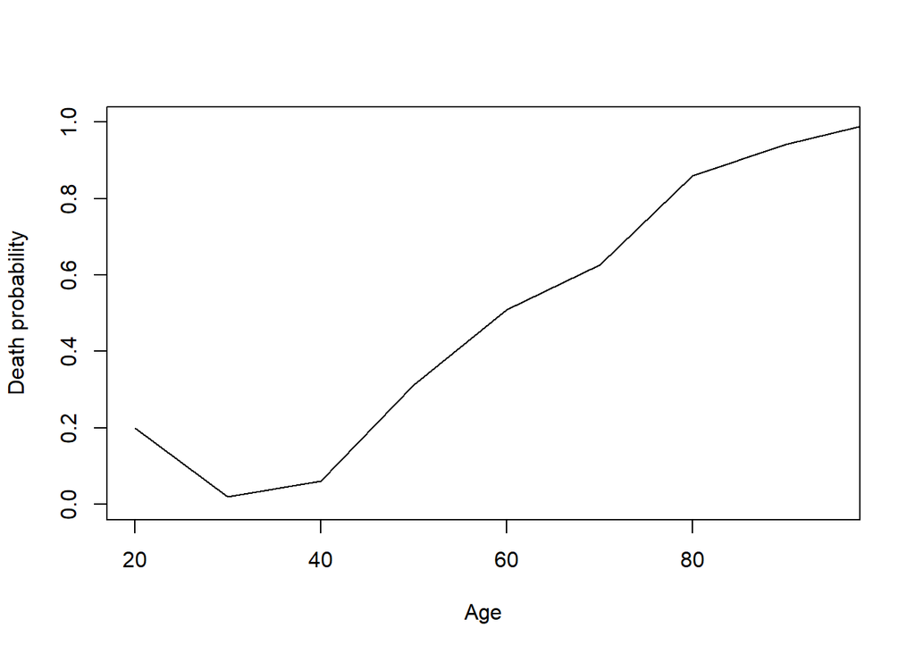

### Gender / Death count

```
## # A tibble: 2 x 2
##   genderStr outcome
##   <chr>       <int>
## 1 female         48
## 2 male          126
```

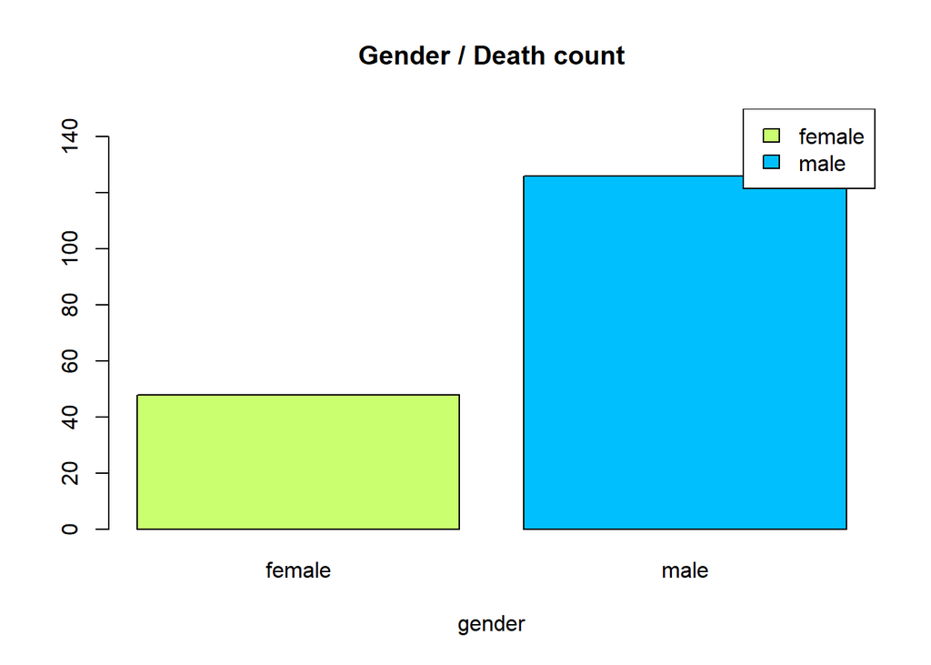

### Gender / Death percentage

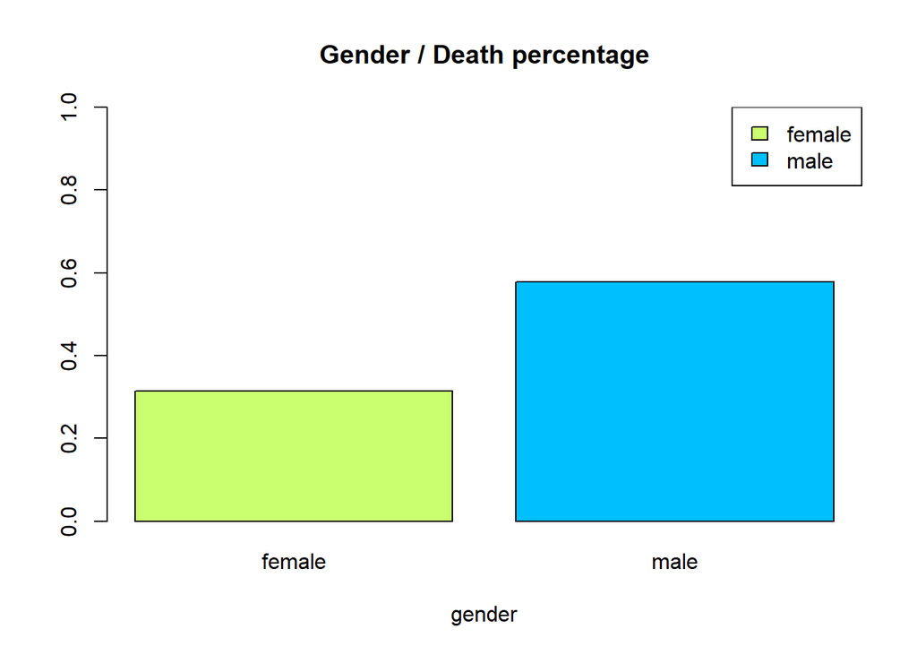

### LDH amount / Death corelation

Threshold value - 70

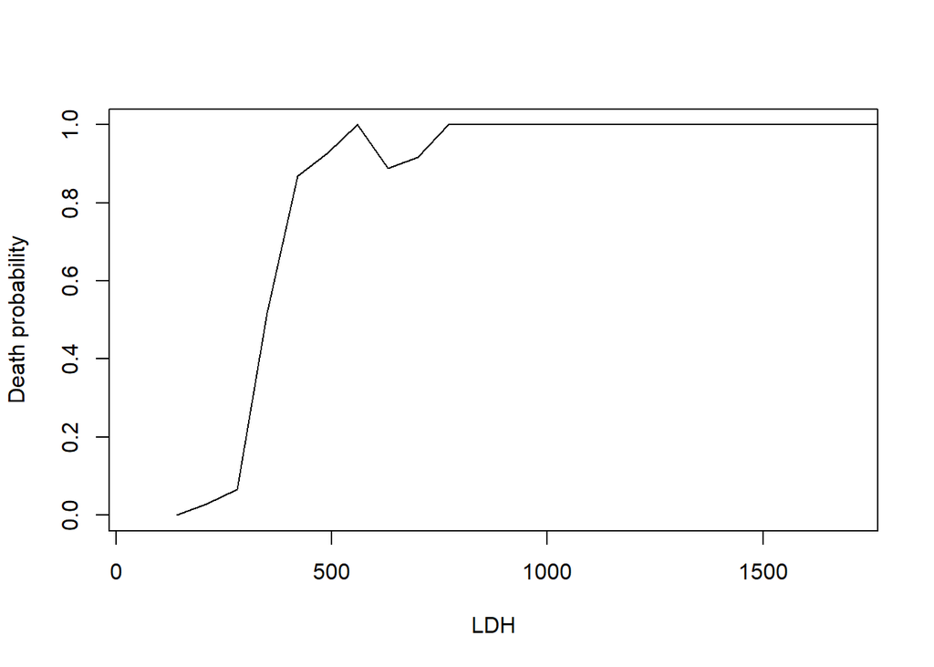

### HS-CRP amount / Death corelation

Threshold value - 25

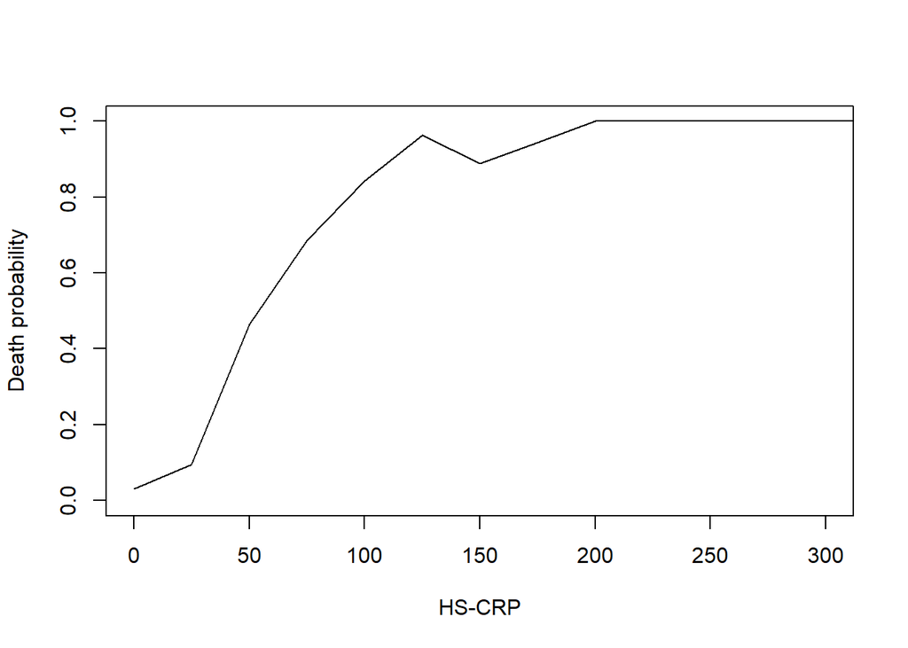

### Lymphocyte (%) / Death Ratio

Threshold value - 10

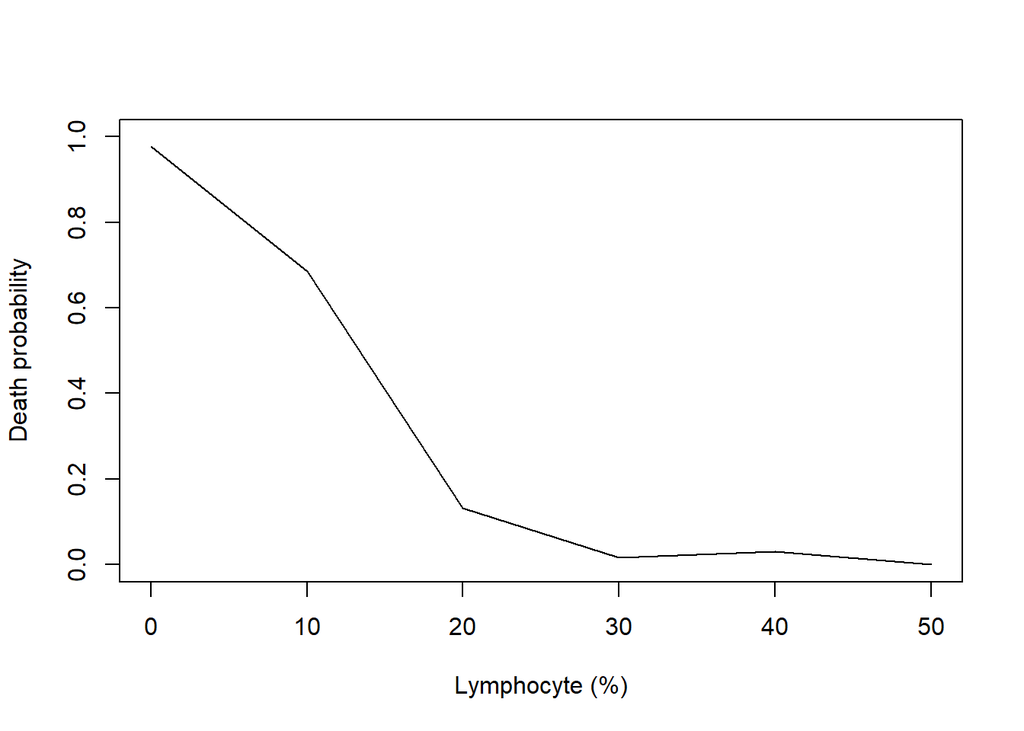

# Predykcja

Do utworzenia klasyfikatora predykującego czy pacjent przeżyje czy nie, wykorzystane zostały trzy cechy, które dzięki wcześniejszym przeanalizowaniu danych dawały przesłanki iż pełnią one istotną rolę w przeżywalności pacjenta. Tymi parametrami są: LDH, HS-CRP oraz procentowa liczba limfocytów we krwii.

W pierwszej kolejności, po wgraniu danych z pliku CSV, dodana została kolumna Class, informująca o tym czy pacjent przeżył, czy nie. Po dodaniu kolumny Class, wypełnione zostały wszystkie wiersze DataFrame, które nie posiadały ID pacjenta - ze struktury dokumentu można było wywnioskować, że rekordy są posortowane po ID pacjenta, przy czym tylko pierwszy wiersz jest oznaczany ID - aby wypełnić brakujące wiersze wykorzystano funkcję `fill` z pakietu `tidyr`. Ostatnim krokiem, wstępnie obrabiającym dane, była zmiana nazw kolumn na bardziej czytelne.

Po wstępnym przygotowaniu danych, dla każdego pacjenta zostały uśrednione wartości LDH, CRP oraz Limfocytów, a następnie wybrane zostały tylko te kolumn, oraz kolumna Class. Tak przygotowany DataFrame nadawał się do nauki klasyfikatora.

### KNN

KNN - Jeden z najprostszych algorytmów uczących, polegający na dopasowaniu nowego wystąpienia do jednej z kilku grup na podstawie analizy kilku najbliższych mu (najbliższych w n-wymiarowej przestrzeni dla n wybranych cech) innych rekordów.

```
Confusion Matrix and Statistics

          Reference
Prediction DEAD ALIVE
     DEAD    39     6
     ALIVE    0    42

               Accuracy : 0.931
                 95% CI : (0.8559, 0.9743)
    No Information Rate : 0.5517
    P-Value [Acc > NIR] : 5.399e-15

                  Kappa : 0.8626

 Mcnemar's Test P-Value : 0.04123

            Sensitivity : 1.0000
            Specificity : 0.8750
         Pos Pred Value : 0.8667
         Neg Pred Value : 1.0000
             Prevalence : 0.4483
         Detection Rate : 0.4483
   Detection Prevalence : 0.5172
      Balanced Accuracy : 0.9375

       'Positive' Class : DEAD
```

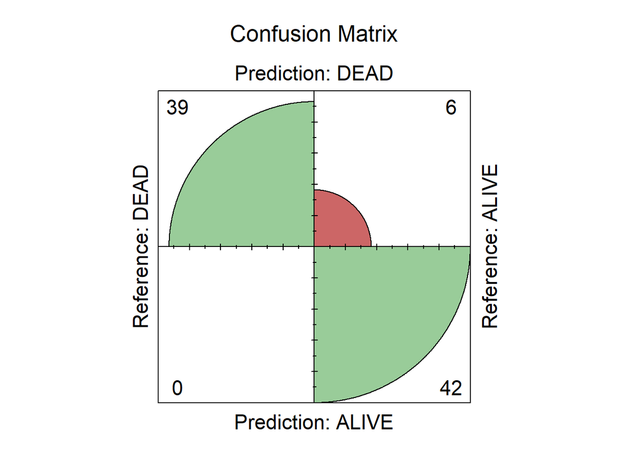

### Naive Bayes:

Metoda naiwny klasyfikator Bayesa jest drugim klasyfikatorem wybranym do zbadania. Opiera się on na prostej probabilistyce. Pomimo jego prostoty, w wielu przypadkach sprawdza się lepiej od skomplikowanych klasyfikatorów

```
Confusion Matrix and Statistics

          Reference
Prediction DEAD ALIVE
     DEAD    38     4
     ALIVE    1    44

               Accuracy : 0.9425
                 95% CI : (0.871, 0.9811)
    No Information Rate : 0.5517
    P-Value [Acc > NIR] : 4.78e-16

                  Kappa : 0.8846

 Mcnemar's Test P-Value : 0.3711

            Sensitivity : 0.9744
            Specificity : 0.9167
         Pos Pred Value : 0.9048
         Neg Pred Value : 0.9778
             Prevalence : 0.4483
         Detection Rate : 0.4368
   Detection Prevalence : 0.4828
      Balanced Accuracy : 0.9455

       'Positive' Class : DEAD
```

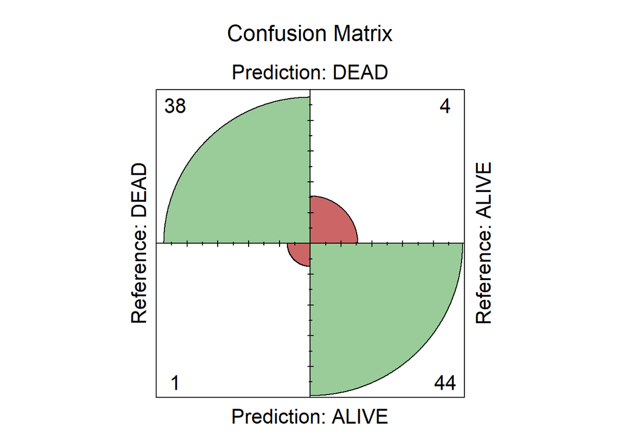

Jak widać z powyższych wyników działania wybranych klasyfikatorów oraz cech wybranych do nauki modelu, trafność obydwu - pomimo iż prostych - klasyfikatorów na ciągu testowym daje bardzo wysokie wyniki. Pokazuje to, że cechy które zostały wybrane do nauki modelu, mogą być istotne w przebiegu choroby. Jednakże, po uśrednieniu wartości wyników morfologicznych, zbiór danych ogranicza się jedynie do 350 pacjentów, co jest bardzo niewielką liczbą danych, dzięki której moglibyśmy z większą pewnością przeanalizować wyniki predykcji wybranych klasyfikatorów, oraz istotność wybranych cech.